# Final Project Part 1

Feng Wang

October 25, 2016

# Metropolis-Hastings

## 1. Algorithm and main function

### Algorithm

- Randomly generate the start value from a uniform distribution
- Built the proposalfunction given in the problem, and generate a possible sample candidate
- Adjust the acceptance probability and apply into comparision
- For the non symmetric distribution, we have $r = \frac{{P(\theta')}/{J(\theta')}}{{P(\theta)}/{J(\theta)}}$
- we compute the posterior and proposal probability, Posterior = $\frac{L(\phi')}{L(\phi)}$, Proposal = $\frac{L'(\phi)}{L'(\phi')}$
- We change the equation and multiple these two number and compare to a random number from a uniform distribution
- If it’s larger add into the chain, otherwise use original value, and do the iterations

### Main function

```r
Beta_MetropolisHastings = function(true_alpha, true_beta, c, iter){
  set.seed(1)
  # start value random from a uniform distribution
  start_value = runif(1); chain = rep(0, iter)
  # the proposal function given in the problem
  proposalfunction = function(c, phi_old){return(rbeta(1, c * phi_old, c * (1 - phi_old)))}
  for (i in 1 : iter){
    # generate a bata sample
    beta = proposalfunction(c, start_value)
    # compute the posterior and propsal value from generated beta
    post = dbeta(beta, true_alpha, true_beta) / dbeta(start_value, true_alpha, true_beta)
    proposal = dbeta(start_value, c * beta, c * (1 - beta)) / dbeta(beta, c * start_value,
                                                                    c * (1 - start_value))
    # if it's in the accept field, add beta into chain, otherwise,
    # use the same value with last element
    if(runif(1) < min(1, post * proposal)){
      start_value = beta
    }
    chain[i] = start_value
  }
  return(chain)
}
```

## 2. Evaluate the performance of the sampler

Variables:  
$\alpha = 6$, $\beta = 4$, c = 1, iteration = 10000

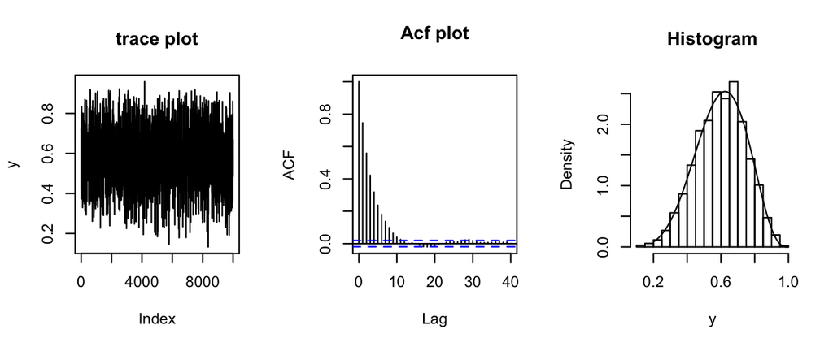

```r
set.seed(1)
true_alpha = 6; true_beta = 4; c = 1; iter = 10000
chain = Beta_MetropolisHastings(true_alpha = 6, true_beta = 4, c = 1, iter = 10000)
par(mfrow = c(1, 3))  #1 row, 3 columns
plot(chain, type = "l",main = "trace plot", ylab = "y")
acf(chain, main = "Acf plot")
hist(chain,freq = FALSE, main = "Histogram", xlab = "y")
grid = seq(0.2,1,length = 300)
beta_density = dbeta(grid, true_alpha, true_beta)
lines(grid,beta_density)
```

### Comparision

In the histogram plot, I change the histogram from frequency to density and also add the true beta(6,4) density line in the graph. It seems that the generated samples follow a beta distribution. The following graph shows the true beta distribution with emprical density.

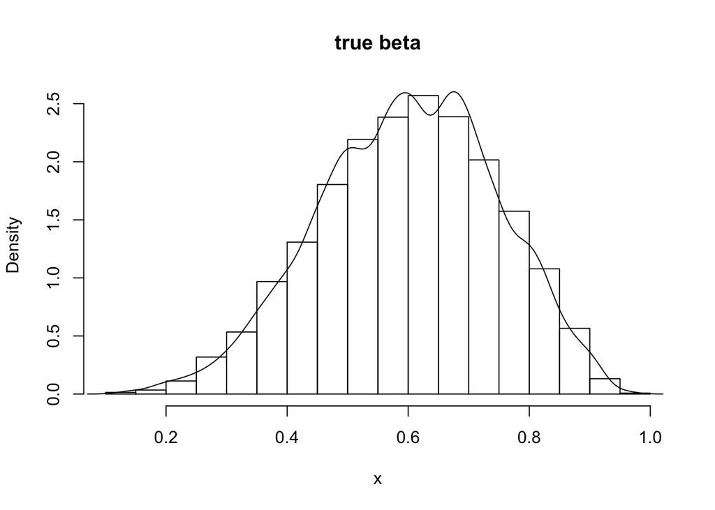

```r
x = rbeta(iter, 6, 4)
hist(x, freq = FALSE, main = "true beta")
lines(density(chain))
```

```r
ks.test(chain[-(1:5000)], x)
```

```
##
##  Two-sample Kolmogorov-Smirnov test
##
## data:  chain[-(1:5000)] and x
## D = 0.0186, p-value = 0.199
## alternative hypothesis: two-sided
```

Burin the first 5000 samples, and compare the random data from beta(6,4). The Kolmogorov-Smirnov test show that the p-value is greater than 0.05, which means that we can NOT reject the null hypothesis. Then we can conclude that data may follow beta distribution.

## 3. Re-run the sample with more parameter

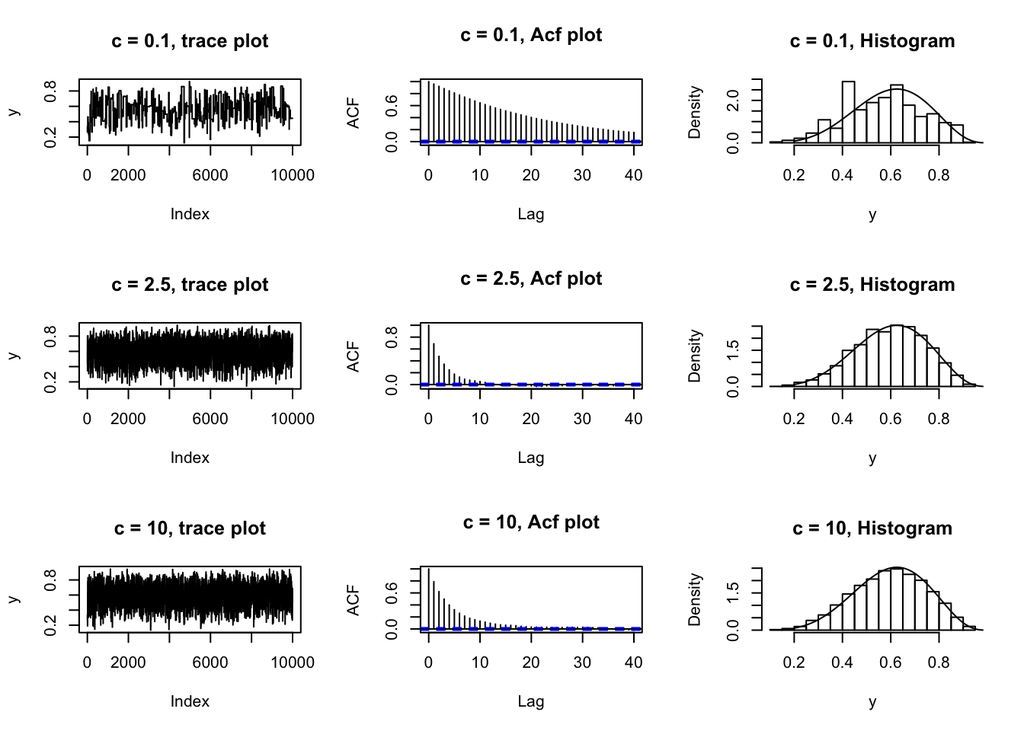

```r
c1 = 0.1; c2 = 2.5; c3 = 10
chain1 = Beta_MetropolisHastings(true_alpha = 6, true_beta = 4, c = c1, iter = 10000)
chain2 = Beta_MetropolisHastings(true_alpha = 6, true_beta = 4, c = c2, iter = 10000)
chain3 = Beta_MetropolisHastings(true_alpha = 6, true_beta = 4, c = c3, iter = 10000)
grid = seq(0.2,1,length = 300)
beta_density = dbeta(grid, true_alpha, true_beta)

par(mfrow = c(3, 3))
plot(chain1, type = "l",main = "c = 0.1, trace plot", ylab = "y")
acf(chain1, main = "c = 0.1, Acf plot")
hist(chain1, freq = FALSE, main = "c = 0.1, Histogram", xlab = "y")
lines(grid, beta_density)
plot(chain2, type = "l",main = "c = 2.5, trace plot", ylab = "y")
acf(chain2, main = "c = 2.5, Acf plot")
hist(chain2, freq = FALSE, main = "c = 2.5, Histogram", xlab = "y")
lines(grid, beta_density)
plot(chain3, type = "l",main = "c = 10, trace plot", ylab = "y")
acf(chain3, main = "c = 10, Acf plot")
hist(chain3, freq = FALSE, main = "c = 10, Histogram", xlab = "y")
lines(grid, beta_density)
```

### Analysis 1

From the trace, Acf plots and histograms, we find that when c = 2.5, it has the best fit for beta distribution and least autocorrelation. For smaller c or larger c, it has high autocorrelation, and the samples should be generated independently. Therefore, c = 2.5 would be the most effective at drawing from the target distribution.

### Analysis 2

Consider different number of draws with Kolmogorov-Smirnov test:

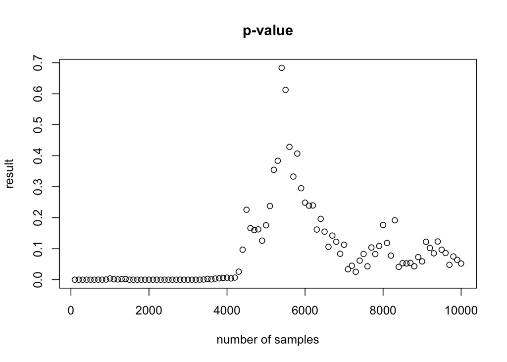

```r
x = rbeta(iter, 6, 4); result = c()
par(mfrow = c(1, 1))
sample = Beta_MetropolisHastings(true_alpha = 6, true_beta = 4, c = 2.5, iter = 10000)
for(i in 1:100){
  result = c(result, ks.test(sample[1:(i*100)],x)$p.value)
}
plot((1:100)*100,result, main = "p-value", xlab = "number of samples")
```